# Analyzing X Std Exam performance for 2011 Karnataka State Board, India

### Kaveri Gita Nadhamuni - August 2014

# Study 3 - Do private school students perform better than government school students?

## Primary schools

The pie chart below shows the number and percentage of government and private primary schools. I used primary school data from Sarva Shiksha Abhiyan to make it as the ‘Karnataka 2011 X std results dataset’ only contains secondary school data.

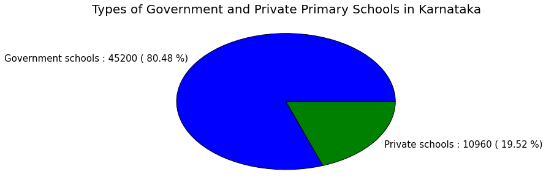

```python
%matplotlib inline
from pylab import *
import pandas as pd
import numpy as np
import matplotlib.pyplot as plt

rcParams['figure.figsize'] = 8,5


marks = pd.read_csv('/Users/Kaveri/Documents/Internship/Karnataka SSLC results/2011.csv')

#setting options for table
pd.set_option('display.width', 200)
pd.set_option('max_columns',15)

#Number of primary government and private school studentsaccording to Sarva Shiksha Abhiyan
pgov = 45200
ppriv = 10960
ptot=56160

#Making the pie chart
plt.figure()
values = [pgov, ppriv]
#Labels of the pie sections

labels = [(' '.join(map(str,('Government schools',':', pgov,'(',round(float(pgov*100)/ptot,2),'%'')')))),(' '.join(map(str,('Private schools',':',ppriv,'(',round(float(ppriv*100)/ptot,2),'%'')'))))]


plt.pie(values, labels=labels)
plt.title('Types of Government and Private Primary Schools in Karnataka')
plt.rcParams['font.size'] = 15
plt.show()
```

One such measure to ensure universal primary education is the Mid Day meal scheme. The Mid Day Meal Scheme is a project of the Government of India intended to improve the nutritional status of school-age children nation wide. The programme supplies free lunches for children in Primary classes in government and government aided schools. This acts as an incentive for parents to place their children in school in the Primary grades.

For many parents, taking care of young children may be burdensome as they have to go to work. Hence, leaving their kids at school becomes a solution to this problem. This too accounts for the large number of students in Primary school.

### Secondary schools

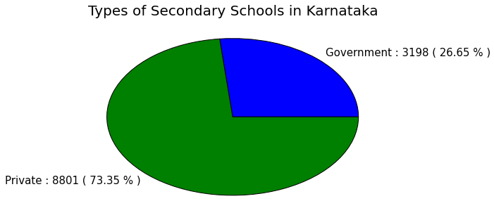

```python
import pandas as pd
import matplotlib.pyplot as plt

rcParams['figure.figsize'] = 8,5
plt.rcParams['font.size'] = 15
marks = pd.read_csv('/Users/Kaveri/Documents/Internship/Karnataka SSLC results/2011.csv')

#setting options for table
pd.set_option('display.width', 200)
pd.set_option('max_columns',15)
govtschools = marks[marks['GVP']=='GOVT']
privschools = marks[marks['GVP']=='PRIVT']


govtschools = marks[marks['GVP']=='GOVT']
privschools = marks[marks['GVP']=='PRIVT']

sgov = len(govtschools['SCHOOL_NAME'].unique())
spriv = len(privschools['SCHOOL_NAME'].unique())
stot = len(marks['SCHOOL_NAME'].unique())


values = [sgov, spriv]
labels = [(' '.join(map(str,('Government',':',sgov,'(',round(float(sgov*100)/stot,2),'%',')')))),(' '.join(map(str,('Private',':',spriv,'(',round(float(spriv*100)/stot,2),'%',')'))))]
plt.pie(values, labels=labels)
plt.title('Types of Secondary Schools in Karnataka')
plt.show()
```

In the pie chart depicting secondary schools below, 73.35% of the schools (8801) are private schools and the remaining 26.65% (3198 schools) are government schools, adding up to a total of 11999 secondary schools.

The number of secondary schools is only 1/5th the number of primary schools. The likely reason for this is that a large numbers of students are dropping out before they can reach secondary school. A study from Human rights watch showed that over 40% of students in India dropout of school before completing 8th grade (http://www.hrw.org/news/2014/04/22/qa-talking-discrimination-and-school-dropout-rates-india). There could be a host of reasons for this: (a) Universal secondary education is not mandatory and hence the education ministry may not have a large budget for it. This is manifest in the fewer secondary schools and lack of Mid day meal scheme, resulting in lower enrollment.

1. Children may be required to work with their parents to sustain their families
2. The village or city they live in may not have secondary schools in the vicinity
3. They may be discouraged by their family and community from taking up further study.

The number of government secondary schools is only 7% of the number of primary government schools. The number of secondary private schools, however, is 80% of the number of primary private schools. The positions of the government and private schools appear to be reversed in the secondary school pie chart.

To summarize, a majority of primary schools are government schools (80%) and a majority of secondary schools are private schools (73%).This implies that students/families that opt for higher education seem to prefer private schools over govt schools.

People who sent their children to private schools for primary education are likely to be more education oriented and are from middle class. They would likely be th ones to send their children to private schools for secondary education.

### Private v/s Govt. School Performance

I plotted the below bar graph that compares the average marks of the private school and public school students for every subject.

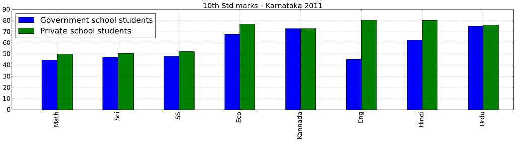

```python
%matplotlib inline
from pylab import *
import pandas as pd
import numpy as np
import matplotlib.pyplot as plt

rcParams['figure.figsize'] = 25, 5
plt.rcParams['font.size'] = 18
plt.rcParams['axes.titlesize'] = 20

x=float('nan')
marks = pd.read_csv('/Users/Kaveri/Documents/Internship/Karnataka SSLC results/2011.csv')

#setting options for table
pd.set_option('display.width', 200)
pd.set_option('max_columns',50)

govt = marks[marks['GVP']=='GOVT']
priv = marks[marks['GVP']!='GOVT']


govtmarks = [

govt['Mathematics'].mean()	,
govt['Science'].mean(),
govt['Social Science'].mean(),
govt['Indian Economics'].mean(),
govt['Kannada'].mean(),

govt['English'].mean() ,

govt['Hindi'].mean() ,
govt['Urdu'].mean() ,
]

govtmean= np.nanmean(govtmarks)

#print 'Mean of Govt Marks for all subjects'
#print govtmarks.mean()

privmarks = [

priv['Mathematics'].mean()	,
priv['Science'].mean(),
priv['Social Science'].mean(),
priv['Indian Economics'].mean(),
priv['Kannada'].mean(),

priv['English'].mean() ,

priv['Hindi'].mean() ,
priv['Urdu'].mean() ,

]


privmean= np.nanmean(privmarks)
subjects = pd.Series(['Math', 'Sci','SS', 'Eco', 'Kannada', 'Eng', 'Hindi', 'Urdu'])
x = pd.DataFrame({'Private school students':privmarks,
                  'Government school students':govtmarks}, index = subjects)


x.plot(kind='bar', title = '10th Std marks - Karnataka 2011')
```

The graph shows that the private school students have outscored the government school students in every subject. The difference between their scores is highest in English where the private school score exceeded the government school score by 35.46 marks. The difference between their scores is least in Kannada where the private school score exceeded the government school score by only 0.11 marks. It is clear that private school students are doing better.

### Dataset and Tools Used

I used Python programming language in conjunction with the Pandas statistical package. I used the ‘Karnataka 2011 X std results dataset’, which consisted of 855,000 students’ records.

### Conclusion:

In summary, there are 5 times as many primary schools as there are secondary schools because a lot of the students in primary schools are dropping out and not entering secondary school. This could be due to their family commitments and the need to take up a job, the lack of secondary schools nearby or societal pressure not to take up secondary school.

Another inference in the study is a majority of the primary schools are government schools and a majority of the secondary schools are private. This shows that students going to government primary schools are more likely to drop out or enter private schools for secondary schools. Whereas most of the students in private primary schools tend to stay on for secondary school.

Additionally, private school students have fared better than Government school students in every subject. In english, the gap between the private and government school students' average scores is highest, whereas in Kannada, the gap between their scores is lowest. This indicates that english is not being taught very well and Kannada is being taught well in government schools.

### References

A study from Human rights watch showing the dropout rate in India. (http://www.hrw.org/news/2014/04/22/qa-talking-discrimination-and-school-dropout-rates-india).